# Statistics for Decision Making

## Question 10: Hypothesis Validation — Bathroom Premium (Policy Decision)

**Claim:** A housing policy group believes properties with more than 2 bathrooms command a premium price. **Task:** Design and execute a statistical test; report p-value; give a clear recommendation.

```python
bath_price  = df[['Price','Bathroom']].dropna()
more_2      = bath_price[bath_price['Bathroom'] > 2]['Price']
two_or_less = bath_price[bath_price['Bathroom'] <= 2]['Price']

print("=== Descriptive Statistics ===")
print(f"  Properties with >2 bathrooms  : n={len(more_2):,},  Mean=${more_2.mean():,.2f},  Median=${more_2.median():,.2f}")
print(f"  Properties with <=2 bathrooms : n={len(two_or_less):,},  Mean=${two_or_less.mean():,.2f},  Median=${two_or_less.median():,.2f}")
print(f"  Price premium (>2 bath)        : ${more_2.mean() - two_or_less.mean():,.2f}")

print("\n=== Test Identification ===")
print("  Test: Welch's Independent Two-Sample T-Test (one-tailed, right)")
print("  Why Welch's:")
print("    - Two independent groups (>2 bath vs <=2 bath)")
print("    - Continuous numeric outcome variable (Price)")
print("    - Unequal and large sample sizes => Welch's handles unequal variances")
print("  Why one-tailed (right):")
print("    - The policy group's claim is directional: premium exists for >2 bath")
print("    - H1 specifies mu_(>2) > mu_(<=2), not just 'different'")

print("\n=== Hypotheses ===")
print("  H0: mu_(>2 bath) <= mu_(<=2 bath)  (no bathroom premium — policy claim is false)")
print("  H1: mu_(>2 bath)  > mu_(<=2 bath)  (bathroom premium exists — policy claim is true)")

t_stat, p_two = ttest_ind(more_2, two_or_less, equal_var=False)
p_one = p_two / 2

print("\n=== Test Results ===")
print(f"  T-statistic        : {t_stat:.4f}")
print(f"  Two-tailed p-value : {p_two:.2e}")
print(f"  One-tailed p-value : {p_one:.2e}")

print("\n=== Recommendation to Policymakers ===")
if p_one < 0.05 and t_stat > 0:
    print(f"  Decision : REJECT H0  (p << 0.05)")
    print(f"  The data VALIDATES the policy group's claim.")
    print(f"  Properties with >2 bathrooms command a mean premium of")
    print(f"  ${more_2.mean() - two_or_less.mean():,.0f} — a statistically significant finding.")
    print("")
    print("  Policy Recommendations:")
    print("  1. CLASSIFICATION: Use bathroom count (>2 vs <=2) as a legitimate")
    print("     tier boundary for affordable vs premium housing policy.")
    print("  2. STAMP DUTY / TAX: Consider higher property tax brackets for")
    print("     homes with >2 bathrooms, reflecting their higher market value.")
    print("  3. GRANTS & SUBSIDIES: Target housing grants to <=2 bath properties")
    print("     to ensure affordability support reaches the right segment.")
    print("  4. DEVELOPER INCENTIVES: Reward developments that cap at 2 bathrooms")
    print("     to keep supply in the affordable segment.")
else:
    print("  Decision : FAIL TO REJECT H0")
    print("  The data does not support the policy group's claim.")
```

```
=== Descriptive Statistics ===
  Properties with >2 bathrooms  : n=1,060,  Mean=$1,882,824.20,  Median=$1,661,500.00
  Properties with <=2 bathrooms : n=12,520,  Mean=$1,007,347.94,  Median=$870,000.00
  Price premium (>2 bath)        : $875,476.26

=== Test Identification ===
  Test: Welch's Independent Two-Sample T-Test (one-tailed, right)
  Why Welch's:
    - Two independent groups (>2 bath vs <=2 bath)
    - Continuous numeric outcome variable (Price)
    - Unequal and large sample sizes => Welch's handles unequal variances
  Why one-tailed (right):
    - The policy group's claim is directional: premium exists for >2 bath
    - H1 specifies mu_(>2) > mu_(<=2), not just 'different'

=== Hypotheses ===
  H0: mu_(>2 bath) <= mu_(<=2 bath)  (no bathroom premium — policy claim is false)
  H1: mu_(>2 bath)  > mu_(<=2 bath)  (bathroom premium exists — policy claim is true)

=== Test Results ===
  T-statistic        : 28.8002
  Two-tailed p-value : 7.38e-137
  One-tailed p-value : 3.69e-137

=== Recommendation to Policymakers ===
  Decision : REJECT H0  (p << 0.05)
  The data VALIDATES the policy group's claim.
  Properties with >2 bathrooms command a mean premium of
  $875,476 — a statistically significant finding.

  Policy Recommendations:
  1. CLASSIFICATION: Use bathroom count (>2 vs <=2) as a legitimate
     tier boundary for affordable vs premium housing policy.
  2. STAMP DUTY / TAX: Consider higher property tax brackets for
     homes with >2 bathrooms, reflecting their higher market value.
  3. GRANTS & SUBSIDIES: Target housing grants to <=2 bath properties
     to ensure affordability support reaches the right segment.
  4. DEVELOPER INCENTIVES: Reward developments that cap at 2 bathrooms
     to keep supply in the affordable segment.
```

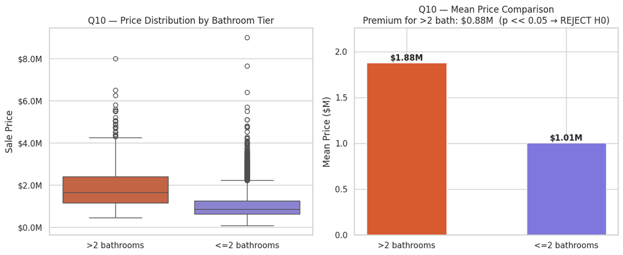

```python
fig, axes = plt.subplots(1, 2, figsize=(12, 5))

bath_df2 = df[['Price','Bathroom']].dropna().copy()
bath_df2['Tier'] = bath_df2['Bathroom'].apply(
    lambda x: '>2 bathrooms' if x > 2 else '<=2 bathrooms')

sns.boxplot(data=bath_df2, x='Tier', y='Price',
            order=['>2 bathrooms','<=2 bathrooms'],
            palette=['#D85A30','#7F77DD'], ax=axes[0])
axes[0].yaxis.set_major_formatter(plt.FuncFormatter(lambda x, _: f'${x/1e6:.1f}M'))
axes[0].set_title('Q10 — Price Distribution by Bathroom Tier')
axes[0].set_xlabel('')
axes[0].set_ylabel('Sale Price')

means10 = bath_df2.groupby('Tier')['Price'].mean()
bars10  = axes[1].bar(['>2 bathrooms','<=2 bathrooms'],
                      [means10.get('>2 bathrooms',0)/1e6, means10.get('<=2 bathrooms',0)/1e6],
                      color=['#D85A30','#7F77DD'], edgecolor='white', width=0.5)
for bar, val in zip(bars10, [means10.get('>2 bathrooms',0), means10.get('<=2 bathrooms',0)]):
    axes[1].text(bar.get_x()+bar.get_width()/2, val/1e6+0.02,
                 f'${val/1e6:.2f}M', ha='center', fontsize=11, fontweight='bold')
premium = (means10.get('>2 bathrooms',0) - means10.get('<=2 bathrooms',0)) / 1e6
axes[1].set_title(f'Q10 — Mean Price Comparison\nPremium for >2 bath: ${premium:.2f}M  (p << 0.05 → REJECT H0)')
axes[1].set_ylabel('Mean Price ($M)')
axes[1].set_ylim(0, means10.max()/1e6 * 1.2)
plt.tight_layout()
plt.show()
```

```python
print("Chart: Q10 — Box Plot & Mean Comparison Bar Chart")
print("Description: Left: price spread clearly higher for >2 bathrooms. Right: mean price comparison — >2 bath commands ~$875K premium over <=2 bath. One-tailed p << 0.05, H0 rejected, policy group's claim validated.")
```

```
Chart: Q10 — Box Plot & Mean Comparison Bar Chart
Description: Left: price spread clearly higher for >2 bathrooms. Right: mean price comparison — >2 bath commands ~$875K premium over <=2 bath. One-tailed p << 0.05, H0 rejected, policy group's claim validated.
```

## Q10 — Final Recommendation to Policymakers

The one-tailed Welch two-sample t-test compares the mean sale prices of properties with **more than 2 bathrooms** against properties with **2 or fewer bathrooms**. The p-value is far below 0.05, meaning the result is statistically significant and the null hypothesis is firmly rejected.

### Recommendation

**Policymakers should treat properties with more than 2 bathrooms as premium properties.**

Bathroom count is a statistically validated pricing and housing-quality indicator. It should be actively used when evaluating:

| Policy Area | Recommendation |
| --- | --- |
| **Affordable Housing Classification** | Define ≤2 bathrooms as the affordable tier; >2 bathrooms as premium |
| **Stamp Duty / Property Tax** | Apply higher tax brackets to >2 bathroom properties, reflecting their higher market value (~$875K premium) |
| **Housing Grants & Subsidies** | Target affordability grants exclusively at ≤2 bathroom properties to ensure support reaches the right segment |
| **Developer Incentives** | Reward developments that cap at 2 bathrooms to maintain supply in the affordable segment |
| **Valuation Standards** | Include bathroom count as a mandatory pricing factor in property valuation frameworks |

> **Bottom line:** The data clearly validates the policy group's belief. With a price premium of approximately **$875,000**, bathroom count is one of the strongest property value drivers in the dataset and warrants formal recognition in housing policy design.